# Lab 8

Martin Hsu

mshsu@calpoly.edu

## Setup

```python
import mysql.connector
from mysql.connector import Error

import pandas as pd
import matplotlib.pyplot as plt
```

```python
pwdfileName = 'account.info'
pwdfile = open(pwdfileName, 'r')

contents = pwdfile.read().splitlines()

u = contents[0]
p = contents[1]

hostName = 'mysql.labthreesixfive.com'
portName = '3306'
userName = u
passString = p
dbName = u

# MySQL Connection
try:
    conn = mysql.connector.connect(host=hostName, port=portName,
                                   database='URBANUNREST', user=userName,
                                   password=passString)
    if conn.is_connected():
        p = ''
        print('Connected to ',hostName)
except Error as e:
    print('Connection Error:', e)

conn.autocommit = True
```

```
Connected to  mysql.labthreesixfive.com
```

## Query 1

**For each country where demonstrations of any kind took place, what is the number of cities (excluding the capital) that had demonstrations, and what is the average number of demonstrations per city within each country (excluding the capital)?**

```python
c1 = conn.cursor()
c1.execute("""
SELECT Country, COUNT(*) NCities, AVG(NDemos) AvgDemonstrations
FROM (
    SELECT ct.City, cn.Country, COUNT(*) NDemos
    FROM Countries cn
    JOIN Cities ct ON ct.Country = cn.ISO3
    JOIN Events e ON e.City = ct.CityId
    JOIN ProblemTypes USING(Ptype)
    WHERE (isCapital != 1) AND (ProblemType LIKE '%Demonstration%')
    GROUP BY e.City
) a
GROUP BY Country;
""")
tbl1 = pd.DataFrame(c1)
tbl1.columns = [i[0] for i in c1.description]
if conn.is_connected():
    c1.close()
```

### Table

```python
tbl1
```

|  | Country | NCities | AvgDemonstrations |
| --- | --- | --- | --- |
| 0 | India | 2 | 31.5000 |
| 1 | South Africa | 2 | 44.0000 |
| 2 | Morocco | 1 | 6.0000 |
| 3 | Turkey | 1 | 48.0000 |
| 4 | Pakistan | 1 | 69.0000 |
| 5 | Nigeria | 1 | 29.0000 |
| 6 | China | 2 | 12.5000 |
| 7 | Kazakhstan | 1 | 6.0000 |
| 8 | Myanmar | 1 | 42.0000 |
| 9 | Brazil | 2 | 32.0000 |
| 10 | Vietnam | 1 | 56.0000 |

### Visualization

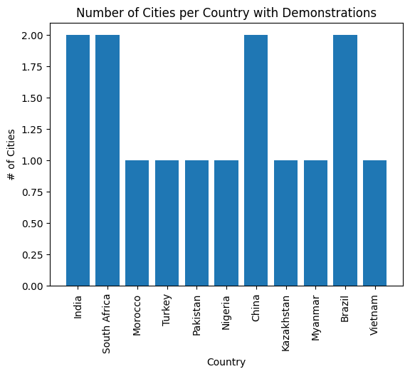

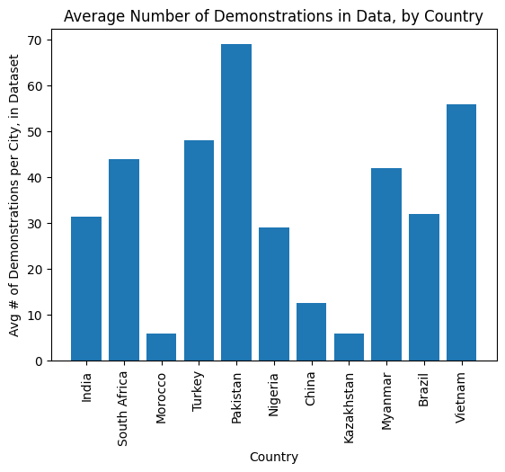

```python
plt.bar(tbl1['Country'], tbl1['NCities'])
plt.xticks(rotation=90)
plt.xlabel('Country')
plt.ylabel('# of Cities')
plt.title('Number of Cities per Country with Demonstrations')
plt.show()

plt.bar(tbl1['Country'], tbl1['AvgDemonstrations'])
plt.xticks(rotation=90)
plt.title('Average Number of Demonstrations in Data, by Country')
plt.xlabel('Country')
plt.ylabel('Avg # of Demonstrations per City, in Dataset')
plt.show()
```

### Explanation

The question aims to gather information about countries where demonstrations occurred. By obtaining these statistics, the question aims to provide an understanding of the extent and distribution of demonstrations across various countries, shedding light on the scale and frequency of protests outside of the capitals.

I accomplished this by: 1) First performing a grouping and aggregation query finding the total number of demonstrations for each city (excluding the country capitals) 2) I then took this table and grouped/aggregated again, this time grouping by country and finding the number of cities with demonstrations as well as the average demonstrations per city for each.

I found out that

- Most demonstrations outside the capital, if any, happened in only 1 or 2 other cities
- Pakistan had the highest average number of demonstrations per city (not the capital)
- Morocco and Kazakhstan had the least nonzero average number of demonstrations per city (not the capital).

## Query 2

**Which specific Latin American cities appear in the top 3 counts (out of all Latin American cities only) for each problem type, and which specific problem types do they rank within the top 3 for? Include ties.**

```python
c2 = conn.cursor()
c2.execute("""
WITH a AS (
    SELECT ct.City, cn.Country, ProblemType, COUNT(*) NEvents
    FROM Events e
    JOIN Cities ct ON e.City = ct.CityId
    JOIN Countries cn ON ct.Country = cn.ISO3
    JOIN ProblemTypes USING(Ptype)
    WHERE (Region = 'Latin America')
    GROUP BY ct.City, cn.Country, ProblemType
), b AS (
    SELECT ProblemType, City, Country, NEvents
    FROM a a1
    JOIN ProblemTypes pt USING(ProblemType)
    WHERE (
        SELECT COUNT(DISTINCT NEvents)
        FROM a a2
        WHERE (a2.ProblemType = pt.ProblemType)
            AND (a2.NEvents > a1.NEvents)
    ) IN (0, 1, 2)
    ORDER BY ProblemType, NEvents DESC
) SELECT City, Country, COUNT(*) NPTypes, GROUP_CONCAT(ProblemType SEPARATOR ', ') ProblemTypes
FROM b
GROUP BY City, Country
ORDER BY NPTypes DESC, City
""")
tbl2 = pd.DataFrame(c2)
tbl2.columns = [i[0] for i in c2.description]
if conn.is_connected():
    c2.close()
```

### Table

```python
tbl2
```

|  | City | Country | NPTypes | ProblemTypes |
| --- | --- | --- | --- | --- |
| 0 | Santiago | Chile | 7 | Spontaneous Demonstration, Anti-Government Ter... |
| 1 | Buenos Aires | Argentina | 6 | Organized Violent Riot, Spontaneous Demonstrat... |
| 2 | Port-Au-Prince | Haiti | 5 | Spontaneous Demonstration, Pro-Government Terr... |
| 3 | San Salvador | El Salvador | 5 | Pro-Government Demonstration, Armed Attack, Ge... |
| 4 | Caracas | Venezuela | 3 | Pro-Government Demonstration, Spontaneous Viol... |
| 5 | Lima | Peru | 3 | General Warfare, Spontaneous Violent Riot, Spo... |
| 6 | Guatemala City | Guatemala | 2 | General Warfare, Armed Attack |
| 7 | Havana | Cuba | 2 | Spontaneous Demonstration, Pro-Government Demo... |
| 8 | La Paz | Bolivia | 2 | Organized Demonstration, Pro-Government Demons... |
| 9 | Panama City | Panama | 2 | General Warfare, Spontaneous Demonstration |
| 10 | Rio De Janeiro | Brazil | 2 | Communal Terrorism, Pro-Government Terrorism (... |
| 11 | Santo Domingo | Dominican Republic | 2 | Armed Battle/Clash, Organized Violent Riot |
| 12 | Sao Paulo | Brazil | 2 | Spontaneous Demonstration, Communal Terrorism |
| 13 | Bogota | Colombia | 1 | Anti-Government Terrorism |
| 14 | Brasilia | Brazil | 1 | Pro-Government Demonstration |
| 15 | Montevideo | Uruguay | 1 | Spontaneous Demonstration |
| 16 | Quito | Ecuador | 1 | Spontaneous Demonstration |
| 17 | Tegucigalpa | Honduras | 1 | General Warfare |

### Visualization

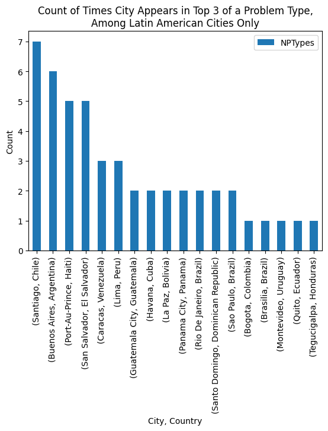

```python
tbl2[['City', 'Country', 'NPTypes']].set_index(['City', 'Country']).plot.bar()
plt.title('Count of Times City Appears in Top 3 of a Problem Type,\nAmong Latin American Cities Only')
plt.xlabel('City, Country')
plt.ylabel('Count')
plt.show()
```

### Explanation

The primary goal of this question is to identify the Latin American city or cities that consistently exhibit high severity across a wide range of problem types. By analyzing the data, the focus is on finding cities that frequently rank in the top 3 for various problems, indicating a pattern of significant challenges across multiple areas. The aim is to highlight the cities where issues tend to have a higher magnitude and occur across different problem types, providing insights into the overall severity of challenges faced by these specific locations in Latin America.

To find the city or cities that showed up the most in the top three counts out of all cities in Latin America: 1) I first created a subquery that for count of events for each city and problem type combination. This query was filtered to the Latin America region. 2) Based on that subquery, I then created a subquery that found the top 3 counts and their cities for each problem type, using a correlated query on the list of unique problem types. 3) Based on the previous subquery, I then used grouping and aggregation to find the number of times each city showed up in the top 3 counts for problem type.

I found out that:

- Santiago, Chile consistently tends to appear in the top 3 counts for the most problem types in Latin America
- The specific problem types Santiago, Chile appears in the top 3 counts for in Latin America are: Pro-Government Demonstration, Organized Violent Riot, Organized Demonstration, Spontaneous Demonstration, Communal Terrorism, Spontaneous Violent Riot, and Anti-Government Terrorism.
- The next top 3 cities that appear most often in top 3 counts by problem type in Latin America are Buenos Aires, Port-Au-Prince and San Salvador.

## Query 3

**Among the set of events that are not labeled as warfare, battles, or attacks: What is the incident with the highest maximum estimated deaths for each unique event target? Exclude unknown max deaths (`maxDeaths`=-1) and limit to where maxDeaths are greater than 100 (inclusive).**

```python
c3 = conn.cursor()
c3.execute("""
WITH a AS(
    SELECT target, eventId, ct.City, cn.Country,
           StartDate, EndDate, ProblemType, maxDeaths
    FROM Events e
    JOIN EventTargets USING(eventId)
    JOIN ProblemTypes USING(PType)
    JOIN Cities ct ON e.City = ct.CityId
    JOIN Countries cn ON ct.Country = cn.ISO3
    WHERE (ProblemType NOT LIKE '%warfare%')
        AND (ProblemType NOT LIKE '%battle%')
        AND (ProblemType NOT LIKE '%attack')
        AND (maxDeaths >= 100)
), b AS (
    SELECT DISTINCT target
    FROM EventTargets
) SELECT target, ProblemType, a1.eventId, City, Country,
         StartDate, EndDate, maxDeaths
FROM a a1
JOIN b USING(target)
WHERE maxDeaths = (
    SELECT MAX(maxDeaths)
    FROM a a2
    WHERE (a2.target = b.target)
) ORDER BY maxDeaths DESC
""")
tbl3 = pd.DataFrame(c3)
tbl3.columns = [i[0] for i in c3.description]
if conn.is_connected():
    c3.close()
```

### Table

```python
tbl3
```

|  | target | ProblemType | eventId | City | Country | StartDate | EndDate | maxDeaths |
| --- | --- | --- | --- | --- | --- | --- | --- | --- |
| 0 | Government | Spontaneous Violent Riot | 18-87 | Beijing | China | 1989-05-23 | 1989-06-04 | 5000 |
| 1 | Civilians | Pro-Government Terrorism (Repression) | 33-113 | Damascus | Syria | 2013-08-21 | 2013-08-21 | 1426 |
| 2 | President Mubarak | Spontaneous Violent Riot | 25-116 | Cairo | Egypt | 2011-01-25 | None | 700 |
| 3 | Demonstrators | Pro-Government Terrorism (Repression) | 15-15 | Baku | Azerbaijan | 1990-01-19 | 1990-01-19 | 600 |
| 4 | Muslims | Spontaneous Violent Riot | 26-3 | Calcutta | India | 1964-01-06 | 1964-01-16 | 500 |
| 5 | Pro-Soviet Government | Spontaneous Violent Riot | 45-22 | Kabul | Afghanistan | 1980-02-21 | 1980-02-28 | 500 |
| 6 | Students | Pro-Government Terrorism (Repression) | 5-43 | Addis Ababa | Ethiopia | 1977-04-29 | 1977-05-01 | 500 |
| 7 | Bus Station | Anti-Government Terrorism | 33-46 | Damascus | Syria | None | None | 400 |
| 8 | Train station | Anti-Government Terrorism | 33-46 | Damascus | Syria | None | None | 400 |
| 9 | Burkinabe migrants | Pro-Government Terrorism (Repression) | 1-40 | Abidjan | Cote d'Ivoire | None | None | 300 |
| 10 | French paratroop company | Anti-Government Terrorism | 19-129 | Beirut | Lebanon | 1983-10-23 | 1983-10-23 | 300 |
| 11 | US Marine battalion | Anti-Government Terrorism | 19-129 | Beirut | Lebanon | 1983-10-23 | 1983-10-23 | 300 |
| 12 | Moslems | Communal Terrorism | 6-74 | Algiers | Algeria | 1962-04-01 | 1962-04-25 | 267 |
| 13 | Police, Swan-ar shan | Organized Demonstration | 79-50 | Rangoon | Myanmar | 2007-09-07 | 2007-09-30 | 200 |
| 14 | SPDC government | Organized Demonstration | 79-50 | Rangoon | Myanmar | 2007-09-07 | 2007-09-30 | 200 |
| 15 | Chinese | Spontaneous Violent Riot | 79-6 | Rangoon | Myanmar | 1967-06-26 | 1967-06-28 | 200 |
| 16 | Police | Organized Violent Riot | 29-3 | Casablanca | Morocco | 1965-03-22 | 1965-03-25 | 199 |
| 17 | Foreigners, ordinary citizens, Jews | Anti-Government Terrorism | 67-54 | Mumbai | India | 2008-11-26 | 2008-11-29 | 195 |
| 18 | Iraqi soldiers | Communal Terrorism | 14-240 | Baghdad | Iraq | 2005-09-14 | 2005-09-14 | 160 |
| 19 | Shiites | Communal Terrorism | 14-240 | Baghdad | Iraq | 2005-09-14 | 2005-09-14 | 160 |
| 20 | RDR supporters | Communal Terrorism | 1-32 | Abidjan | Cote d'Ivoire | 2000-10-26 | 2000-10-26 | 155 |
| 21 | Victims | Anti-Government Terrorism | 35-21 | Dhaka | Bangladesh | 1971-12-13 | 1971-12-14 | 140 |
| 22 | Northerners | Spontaneous Violent Riot | 49-57 | Khartoum | Sudan | 2005-08-01 | 2005-08-04 | 130 |
| 23 | President | Spontaneous Violent Riot | 89-2 | Seoul | South Korea | 1960-04-18 | 1960-04-26 | 117 |
| 24 | Whites | Spontaneous Violent Riot | 62-13 | Maputo | Mozambique | 1974-09-10 | 1974-09-11 | 115 |
| 25 | Pro-extradiction policies | Anti-Government Terrorism | 21-78 | Bogota | Colombia | 1989-11-27 | 1989-11-27 | 107 |
| 26 | M-19 | Pro-Government Terrorism (Repression) | 21-48 | Bogota | Colombia | 1985-11-06 | 1985-11-07 | 106 |
| 27 | TTS | Spontaneous Violent Riot | 10-15 | Antananarivo | Madagascar | 1984-12-04 | 1984-12-04 | 100 |
| 28 | Suchinda | Organized Demonstration | 17-49 | Bangkok | Thailand | 1992-05-17 | 1992-05-19 | 100 |
| 29 | Hausas | Spontaneous Violent Riot | 55-56 | Lagos | Nigeria | 2000-10-12 | 2000-10-18 | 100 |

### Visualization

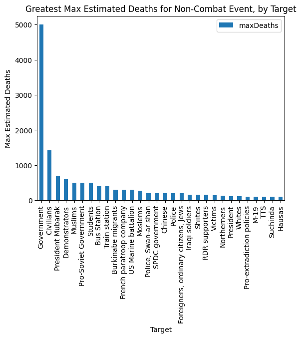

```python
tbl3[['target', 'maxDeaths']].set_index('target').plot.bar()
plt.title('Greatest Max Estimated Deaths for Non-Combat Event, by Target')
plt.xlabel('Target')
plt.ylabel('Max Estimated Deaths')
plt.show()
```

### Explanation

The goal of this question is to provide insights into the magnitude of non-combat-related incidents and highlight those with significant human impact.

I achieved this result by performing the following steps in my query: 1) Selecting the 'non-combat' problem type events and projecting maxDeaths and other event descriptor attributes 2) Getting a list of unique targets 3) Using a correlated query to get the non-combat event with max deaths for each target

I found that:

- The target with the largest max estimated deaths for non-combat event was the government. Based on the table, it looks to be a Chinese incident in 1989, which would probably be the Tiananmen Square incident.

## Query 4

**What is the longest event that started in each year, excluding events for which the exact start and end dates are unknown?**

```python
c4 = conn.cursor()
c4.execute("""
WITH a AS(
    SELECT *, YEAR(StartDate) StartYear, DATEDIFF(EndDate, StartDate) Length
    FROM Events e
), b AS (
    SELECT DISTINCT StartYear
    FROM a
) SELECT StartYear, eventId, ProblemType,
         ct.City, cn.Country, Length
FROM a a1
JOIN b USING(StartYear)
JOIN ProblemTypes USING(PType)
JOIN Cities ct ON a1.City = ct.CityId
JOIN Countries cn ON ct.Country = cn.ISO3
WHERE Length = (
    SELECT MAX(Length)
    FROM a a2
    WHERE (a2.StartYear = b.StartYear)
) ORDER BY StartYear
""")
tbl4 = pd.DataFrame(c4)
tbl4.columns = [i[0] for i in c4.description]
if conn.is_connected():
    c4.close()
```

### Table

```python
tbl4
```

|  | StartYear | eventID | ProblemType | City | Country | Length |
| --- | --- | --- | --- | --- | --- | --- |
| 0 | 1960 | 97-2 | Organized Demonstration | Tokyo | Japan | 21 |
| 1 | 1961 | 30-3 | Organized Demonstration | Colombo | Sri Lanka | 26 |
| 2 | 1962 | 6-67 | Armed Attack | Algiers | Algeria | 97 |
| 3 | 1963 | 9-13 | Spontaneous Violent Riot | Ankara | Turkey | 5 |
| 4 | 1963 | 82-11 | Organized Demonstration | Saigon | Vietnam | 5 |
| 5 | 1964 | 39-15 | Anti-Government Terrorism | Harare | Zimbabwe | 23 |
| 6 | 1965 | 78-4 | Organized Demonstration | Rabat | Morocco | 14 |
| 7 | 1966 | 18-6 | Pro-Government Demonstration | Beijing | China | 100 |
| 8 | 1967 | 82-63 | Organized Demonstration | Saigon | Vietnam | 16 |
| 9 | 1968 | 63-2 | Organized Violent Riot | Mexico City | Mexico | 122 |
| 10 | 1969 | 61-4 | Communal Terrorism | Manila | Philippines | 57 |
| 11 | 1970 | 26-29 | Inter-communal Warfare | Calcutta | India | 213 |
| 12 | 1971 | 61-15 | Communal Terrorism | Manila | Philippines | 124 |
| 13 | 1972 | 10-3 | Spontaneous Violent Riot | Antananarivo | Madagascar | 22 |
| 14 | 1973 | 86-44 | Pro-Government Terrorism (Repression) | Santiago | Chile | 33 |
| 15 | 1974 | 89-18 | Organized Demonstration | Seoul | South Korea | 30 |
| 16 | 1975 | 59-15 | Inter-communal Warfare | Luanda | Angola | 33 |
| 17 | 1976 | 30-13 | Organized Demonstration | Colombo | Sri Lanka | 26 |
| 18 | 1977 | 4-17 | Organized Demonstration | Accra | Ghana | 16 |
| 19 | 1978 | 9-63 | Communal Terrorism | Ankara | Turkey | 89 |
| 20 | 1979 | 96-96 | Pro-Government Terrorism (Repression) | Tehran | Iran | 77 |
| 21 | 1980 | 21-31 | Armed Attack | Bogota | Colombia | 60 |
| 22 | 1981 | 67-23 | Organized Demonstration | Mumbai | India | 90 |
| 23 | 1982 | 27-37 | Organized Demonstration | Cape Town | South Africa | 22 |
| 24 | 1983 | 72-5 | Spontaneous Violent Riot | Niamey | Niger | 16 |
| 25 | 1984 | 61-48 | Communal Terrorism | Manila | Philippines | 48 |
| 26 | 1985 | 57-41 | Anti-Government Terrorism | Lima | Peru | 30 |
| 27 | 1986 | 99-18 | Organized Demonstration | Tunis | Tunisia | 103 |
| 28 | 1987 | 71-94 | Pro-Government Demonstration | New Delhi | India | 49 |
| 29 | 1988 | 19-222 | Anti-Government Terrorism | Beirut | Lebanon | 101 |
| 30 | 1989 | 9-82 | Organized Demonstration | Ankara | Turkey | 36 |
| 31 | 1990 | 79-24 | Organized Demonstration | Rangoon | Myanmar | 44 |
| 32 | 1991 | 64-17 | Armed Battle/Clash | Mogadishu | Somalia | 45 |
| 33 | 1992 | 45-127 | Inter-communal Warfare | Kabul | Afghanistan | 19 |
| 34 | 1993 | 45-134 | General Warfare | Kabul | Afghanistan | 58 |
| 35 | 1994 | 55-36 | Organized Demonstration | Lagos | Nigeria | 62 |
| 36 | 1995 | 84-150 | Organized Demonstration | San Salvador | El Salvador | 65 |
| 37 | 1996 | 43-57 | Organized Demonstration | Jakarta | Indonesia | 45 |
| 38 | 1997 | 23-30 | General Warfare | Brazzaville | Congo | 77 |
| 39 | 1998 | 71-126 | Organized Demonstration | New Delhi | India | 48 |
| 40 | 1999 | 89-113 | Organized Demonstration | Seoul | South Korea | 7 |
| 41 | 2000 | 43-89 | Spontaneous Demonstration | Jakarta | Indonesia | 30 |
| 42 | 2001 | 43-94 | Organized Demonstration | Jakarta | Indonesia | 39 |
| 43 | 2002 | 103-41 | Organized Demonstration | Yerevan | Armenia | 21 |
| 44 | 2003 | 14-75 | General Warfare | Baghdad | Iraq | 11 |
| 45 | 2003 | 1-39 | Spontaneous Violent Riot | Abidjan | Cote d'Ivoire | 11 |
| 46 | 2004 | 88-49 | Organized Demonstration | Sao Paulo | Brazil | 93 |
| 47 | 2005 | 20-12 | Organized Demonstration | Bishkek | Kyrgyzstan | 40 |
| 48 | 2006 | 39-90 | Organized Demonstration | Harare | Zimbabwe | 49 |
| 49 | 2007 | 44-126 | Organized Demonstration | Johannesburg | South Africa | 27 |
| 50 | 2008 | 14-334 | Communal Terrorism | Baghdad | Iraq | 23 |
| 51 | 2009 | 45-222 | Armed Attack | Kabul | Afghanistan | 11 |
| 52 | 2010 | 17-114 | Organized Demonstration | Bangkok | Thailand | 68 |
| 53 | 2011 | 47-237 | Communal Terrorism | Karachi | Pakistan | 30 |
| 54 | 2012 | 55-70 | Organized Demonstration | Lagos | Nigeria | 22 |
| 55 | 2013 | 68-86 | Organized Demonstration | Nairobi | Kenya | 29 |
| 56 | 2014 | 28-107 | Organized Violent Riot | Caracas | Venezuela | 83 |

### Visualization

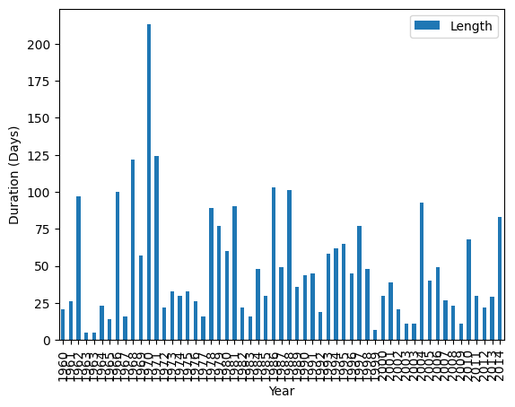

```python
tbl4[['StartYear', 'Length']].set_index('StartYear').plot.bar()
plt.xlabel('Year')
plt.ylabel('Duration (Days)')
plt.show()
```

### Explanation

The goal of this question is to determine, for each year, the longest event that began during that specific year. The aim is to identify events with the longest durations, providing insights into notable occurrences and their durations over time for each year.

I achieved a table that answers this question by doing the following: 1) Finding the duration of each event in the dataset 2) Finding a list of unique years in the dataset 3) Using a correlated query to find the longest event that started in each year, and joining identification attributes to the result.

I found out that:

- The year with a longest event of the greatest duration out of any year was 1970. It was a 'Inter Communal Warfare' event that occurred in Calcutta, India. I tried to look up what specific event this might be without much luck, but it could be related to the Indo-Pakistani Wars that occurred around that period.

## Query 5

**What is the proportion of incidents with deaths involved for each region, considering events starting in the 1960s, 1970s, 1980s, 1990s, 2000s, and overall "for all time"?**

```python
c5 = conn.cursor()
c5.execute("""
SELECT *
FROM (
    SELECT DISTINCT Region
    FROM Countries
) regions
JOIN (
    SELECT Region, SUM(CASE WHEN deathFlag = 1 THEN 1 END) / COUNT(*) AllYears
    FROM Events e
    JOIN Cities ct ON e.City = ct.CityId
    JOIN Countries cn ON ct.Country = cn.ISO3
    GROUP BY Region
) allyears USING(Region)
JOIN (
    SELECT Region, SUM(CASE WHEN deathFlag = 1 THEN 1 END) / COUNT(*) `1960s`
    FROM Events e
    JOIN Cities ct ON e.City = ct.CityId
    JOIN Countries cn ON ct.Country = cn.ISO3
    WHERE (YEAR(StartDate) >= 1960)
        AND (YEAR(StartDate) < 1970)
    GROUP BY Region
) sixties USING(Region)
JOIN (
    SELECT Region, SUM(CASE WHEN deathFlag = 1 THEN 1 END) / COUNT(*) `1970s`
    FROM Events e
    JOIN Cities ct ON e.City = ct.CityId
    JOIN Countries cn ON ct.Country = cn.ISO3
    WHERE (YEAR(StartDate) >= 1970)
        AND (YEAR(StartDate) < 1980)
    GROUP BY Region
) seventies USING(Region)
JOIN (
    SELECT Region, SUM(CASE WHEN deathFlag = 1 THEN 1 END) / COUNT(*) `1980s`
    FROM Events e
    JOIN Cities ct ON e.City = ct.CityId
    JOIN Countries cn ON ct.Country = cn.ISO3
    WHERE (YEAR(StartDate) >= 1980)
        AND (YEAR(StartDate) < 1990)
    GROUP BY Region
) eighties USING(Region)
JOIN (
    SELECT Region, SUM(CASE WHEN deathFlag = 1 THEN 1 END) / COUNT(*) `1990s`
    FROM Events e
    JOIN Cities ct ON e.City = ct.CityId
    JOIN Countries cn ON ct.Country = cn.ISO3
    WHERE (YEAR(StartDate) >= 1990)
        AND (YEAR(StartDate) < 2000)
    GROUP BY Region
) ninties USING(Region)
JOIN (
    SELECT Region, SUM(CASE WHEN deathFlag = 1 THEN 1 END) / COUNT(*) `2000s`
    FROM Events e
    JOIN Cities ct ON e.City = ct.CityId
    JOIN Countries cn ON ct.Country = cn.ISO3
    WHERE (YEAR(StartDate) >= 2000)
        AND (YEAR(StartDate) < 2010)
    GROUP BY Region
) millenium USING(Region)
""")
tbl5 = pd.DataFrame(c5)
tbl5.columns = [i[0] for i in c5.description]
if conn.is_connected():
    c5.close()
```

### Table

```python
tbl5
```

|  | Region | AllYears | 1960s | 1970s | 1980s | 1990s | 2000s |
| --- | --- | --- | --- | --- | --- | --- | --- |
| 0 | Asia | 0.3613 | 0.3184 | 0.3353 | 0.3880 | 0.3636 | 0.3584 |
| 1 | Middle East and North Africa | 0.5607 | 0.4070 | 0.3864 | 0.6236 | 0.5810 | 0.6614 |
| 2 | Sub-Saharan Africa | 0.4591 | 0.3032 | 0.4061 | 0.3721 | 0.4745 | 0.4936 |
| 3 | Latin America | 0.2959 | 0.2690 | 0.3557 | 0.2581 | 0.3215 | 0.3502 |

### Visualization

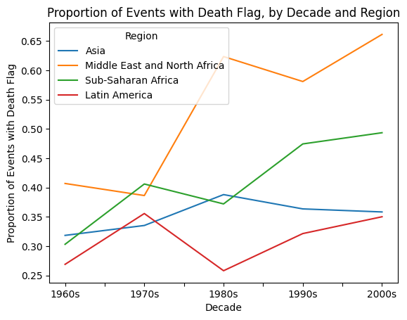

```python
tbl5.set_index('Region').drop('AllYears', axis=1).astype(float).T.plot.line()
plt.title('Proportion of Events with Death Flag, by Decade and Region')
plt.xlabel('Decade')
plt.ylabel('Proportion of Events with Death Flag')
plt.show()
```

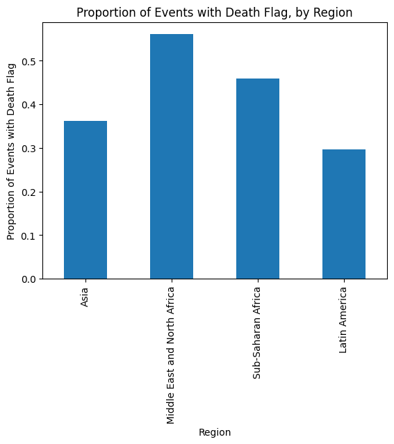

```python
tbl5.set_index('Region')['AllYears'].astype(float).plot.bar()
plt.title('Proportion of Events with Death Flag, by Region')
plt.ylabel('Proportion of Events with Death Flag')
plt.show()
```

### Explanation

The goal of this question is to calculate and report the proportion of incidents with deaths involved for each region. By analyzing events starting in specific decades (1960s, 1970s, 1980s, 1990s, 2000s) as well as considering the cumulative data for "all time," the aim is to assess the frequency of incidents resulting in deaths in different regions. This information provides insights into the relative impact and severity of incidents across regions over different time periods.

I achieved this by doing the following: 1) For each decade (and "for all time"), I created a query that used aggregation and grouping to find the needed proportions. This resulted in 6 tables. 2) I joined all the tables together on region. This was so I could get one column for each decade, which was the format of the output that I believed would most clearly communicate the data.

I found out that:

- Overall, Middle East and North Africa had the highest proportion of events with death flags. Latin America had the lowest proportion of events with death flags.
- Generally, the proportion of events with death flags increased over time. Middle East and North Africa seemed to show the greatest increase between the 1960s and 2000s, while the proportions for Asia and Latin America seemed to not increase as much over time.
- The decade and region combination with the highest proportion of events with deaths flags was the Middle East and North Africa in the 2000s. The combination with the lowest corresponding proportion was Latin America in the 1980s.

```python
if conn.is_connected():
    conn.close()
    print('Done')
```

```
Done
```